# Simulation Results

We investigate 3 methods in this writeup: binary segmentation with fixed number of steps, fused lasso with fixed number of steps, and sample splitting (using the even samples for fitting via binary segmentation with fixed number of steps, odd samples for testing).

## No Jump Simulations

Throughout this section, there is no jump, $n=100$ and $\sigma=1$.

**Selection**

We can investigate where the jumps lie.

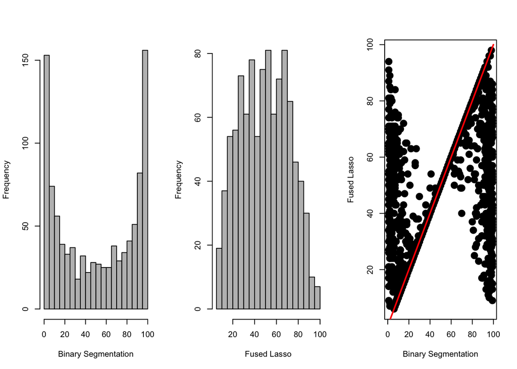

**P Values** These are one-sided p-values. We plot the QQ plots.

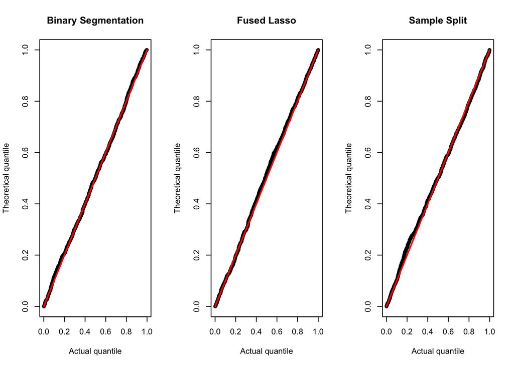

**Confidence Interval**

We can compute the coverage for Binary Segmentation and Fused Lasso respectively.

```r
compute.confidence(bsFs_0JumpCI[[1]])
```

```
## [1] 0.959
```

```r
compute.confidence(flFs_0JumpCI[[1]])
```

```
## [1] 0.96
```

```r
compute.confidence(ss_0JumpCI[[1]])
```

```
## [1] 0.949
```

We can also plot the quantiles of the confidence interval width. Here, the red line denotes the expected length between the 97.5% and 2.5% quantiles of a standard Gaussian.

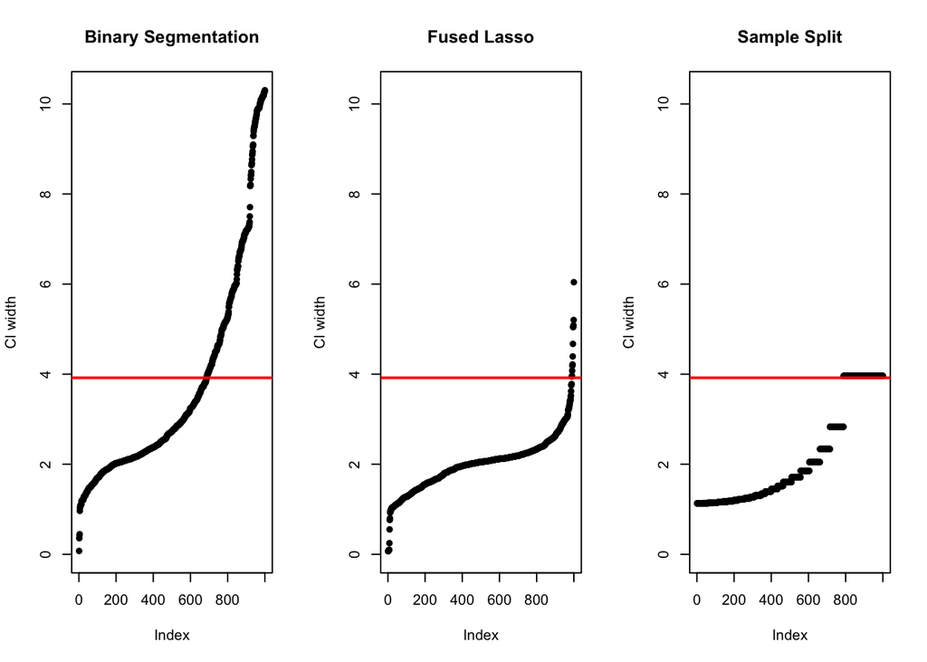

We can also visualize the two-sided confidence intervals.

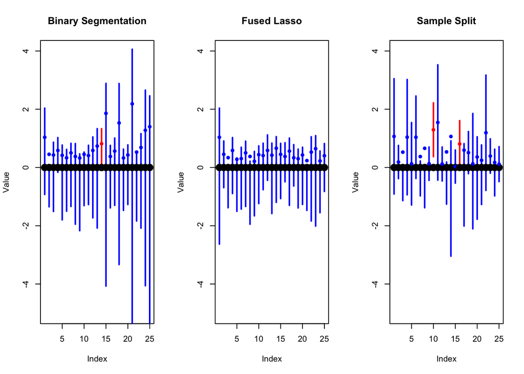

## One Jump Simulation. Fixed n, varying location and height

Here, $n=100$, $\sigma = 1$. The jump height varies from 0.05 to 5, and the jump location varies from 10, 20, … 90. We stop both binary segmentation and fused lasso after one jump. The left-side of the mean signal is always at 0, and the right-side of the mean signal is strictly positive.

**Selection**

We can plot the selected jump location for different settings. First, let’s do a jump height of 0.5 at location 10.

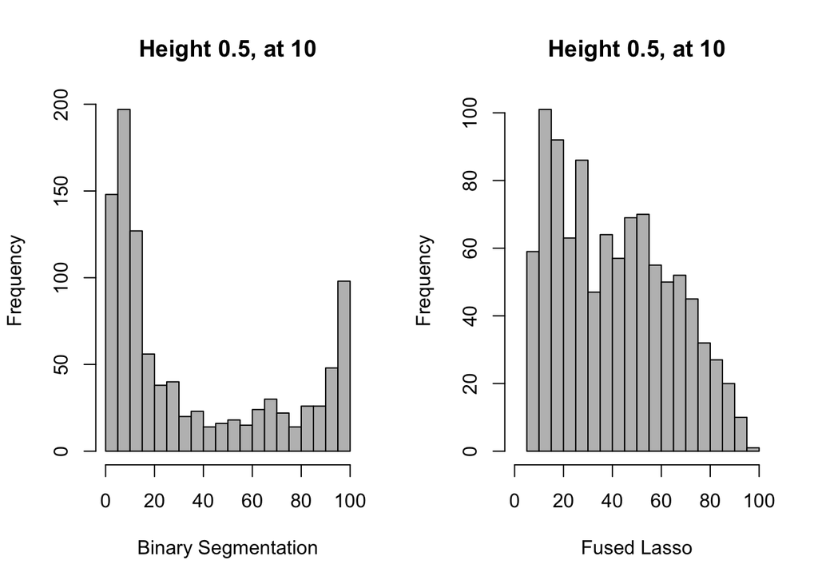

Next, we can do jump height of 1.9 at location 10.

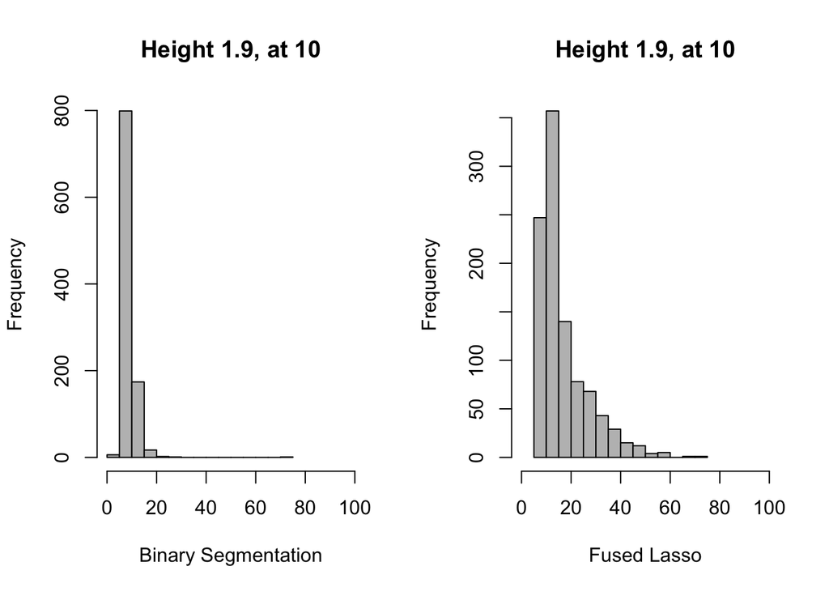

Next, we can do jump height of 0.5 at location 50.

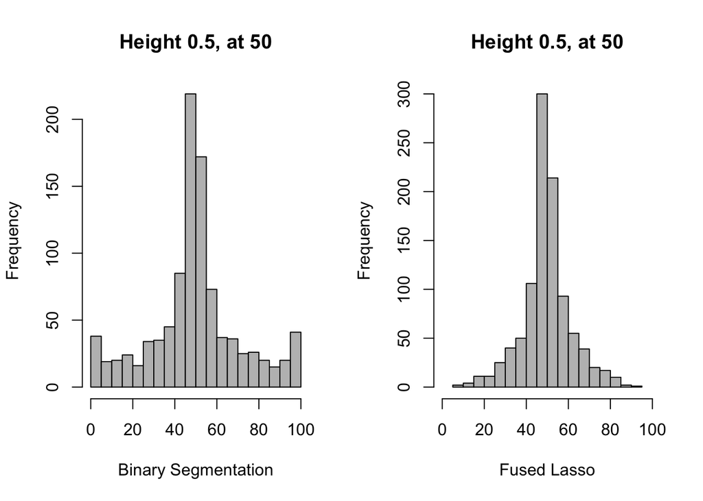

Next, we can do jump height of 1.9 at location 50.

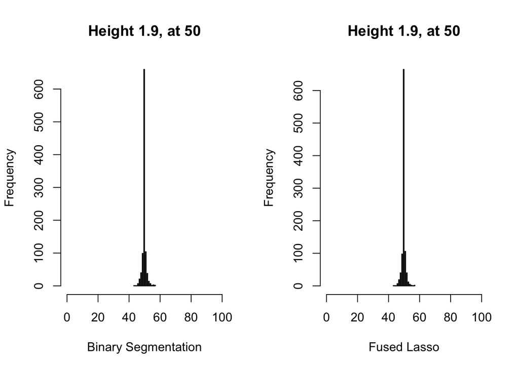

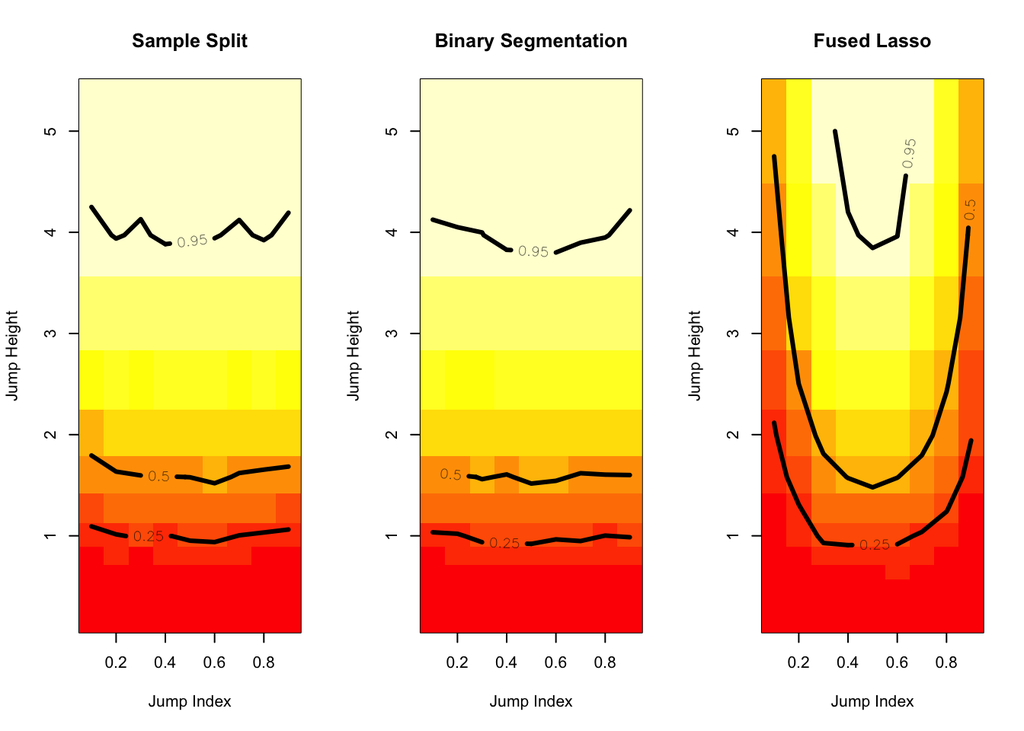

We can also color the plot where each square is determined by the mean absolute distance from the estimated jump to the true jump. Here, the $y$-axis is the log-scale to emphasize the difference. We want as much red in these plot as possible.

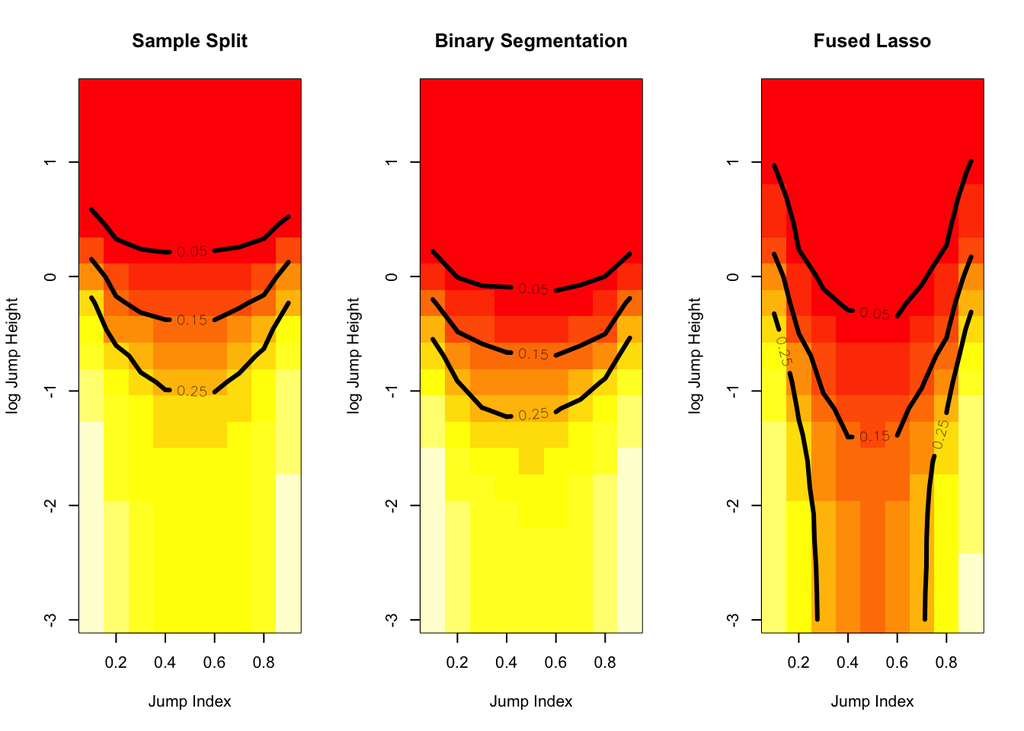

**P Values**

These are one-sided p-values. We can plot the unconditional power where the $y$-axis in the image is the log jump height. We want as much white as possible.

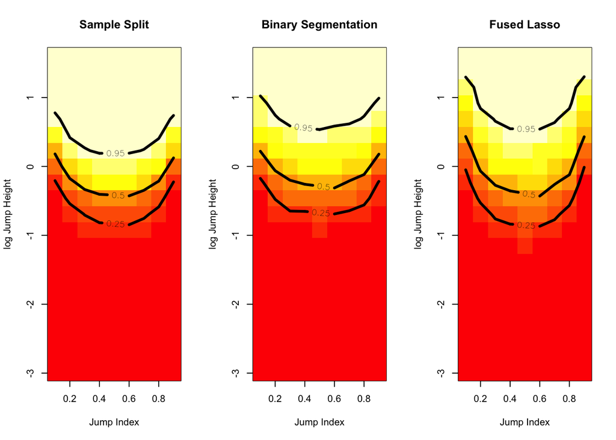

## One Jump Simulation. Fixed height, varying n and location

Here, the jump height is fixed to be 0.25 and $n$ varies from 10 to 1000. As before, the jump location varies from 10, 20, … 90.

**Selection**

We can plot the mean absolute difference between the selected jump and the true jump divided by $n$. We plot the log of $n$ on the $y$-axis. We want this notion of ``spread’’ to be as low as possible when n is small. In the following plot, red is small, white/yellow is big.

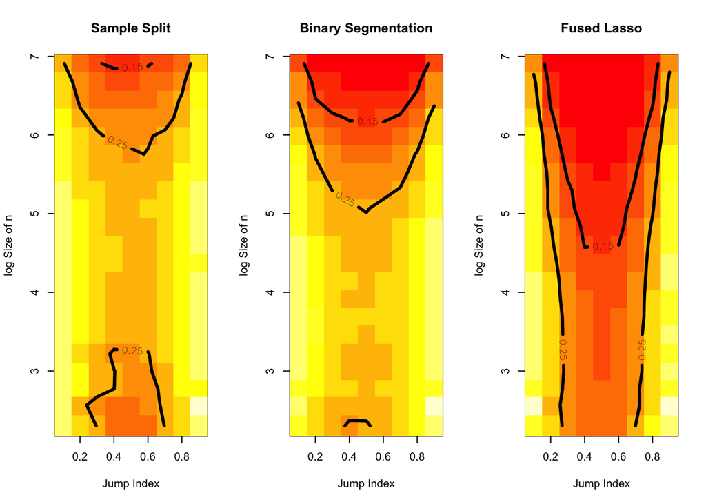

**P Values**

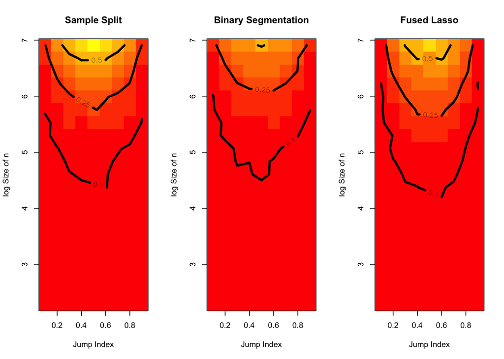